# Clarifying habitat niche width using broad‐scale, hierarchical occupancy models: a case study with a recovering mesocarnivore - Moll - 2016 - Journal of Zoology - Wiley Online Library

[figure not shown]

# Clarifying habitat niche width using broad‐scale, hierarchical occupancy models: a case study with a recovering mesocarnivore

[R. J. Moll](https://zslpublications.onlinelibrary.wiley.com/action/doSearch?ContribAuthorStored=Moll%2C+R+J)

[K. Kilshaw](https://zslpublications.onlinelibrary.wiley.com/action/doSearch?ContribAuthorStored=Kilshaw%2C+K)

[R. A. Montgomery](https://zslpublications.onlinelibrary.wiley.com/action/doSearch?ContribAuthorStored=Montgomery%2C+R+A)

[L. Abade](https://zslpublications.onlinelibrary.wiley.com/action/doSearch?ContribAuthorStored=Abade%2C+L)

[R. D. Campbell](https://zslpublications.onlinelibrary.wiley.com/action/doSearch?ContribAuthorStored=Campbell%2C+R+D)

[L. A. Harrington](https://zslpublications.onlinelibrary.wiley.com/action/doSearch?ContribAuthorStored=Harrington%2C+L+A)

[J. J. Millspaugh](https://zslpublications.onlinelibrary.wiley.com/action/doSearch?ContribAuthorStored=Millspaugh%2C+J+J)

[J. D. S. Birks](https://zslpublications.onlinelibrary.wiley.com/action/doSearch?ContribAuthorStored=Birks%2C+J+D+S)

[D. W. Macdonald](https://zslpublications.onlinelibrary.wiley.com/action/doSearch?ContribAuthorStored=Macdonald%2C+D+W)

First published: 26 June 2016

https://doi.org/10.1111/jzo.12369

Editor: Nigel Bennett

## Abstract

A species’ habitat niche width informs its position on the generalist–specialist continuum, which is central to life‐history theory and crucial to conservation planning. However, assessments of niche width are often based on local‐scale studies or qualitative descriptions rather than broad, quantitative assessments conducted in heterogeneous landscapes. Here, we show how broad‐scale, hierarchical occupancy models can clarify a species’ niche width and degree of habitat specialism by evaluating the woodland‐specialist classification of the European pine marten *Martes martes*. We deployed 526 camera‐trap stations at 27 sites throughout a vast extent (~50 000 km<sup>2</sup>) in Scotland and modeled pine marten occupancy as a function of habitat characteristics using a hierarchical Bayesian analysis. Our model was flexible to trap happiness due to baiting at camera traps and accounted for spatial autocorrelation among and imperfect detection at camera‐trap stations. We detected a positive association between pine marten occupancy probability and wooded habitats. However, pine marten occupancy probability was also high in numerous non‐wooded habitats, including agricultural land, heather and heather grassland, semi‐natural grassland and areas near anthropogenic structures. Our study is the first to record high pine marten occupancy in open habitats at broad spatial scales and thereby corroborates recent smaller scale indications that pine martens are more of a habitat generalist than previously thought. Our results guide ongoing conservation efforts by identifying that pine martens are not strict woodland specialists, but rather inhabit a mosaic of habitat types in the landscape. More broadly, our case study exemplifies how coupling hierarchical occupancy models with large‐scale experimental designs can clarify a species’ niche width and associated position on the generalist–specialist continuum.

## Introduction

Correctly positioning species along the generalist–specialist continuum is central to life‐history theory and has important implications for conservation planning. For instance, genetic isolation (Futuyma & Moreno, 1988), effective population size (Zayed *et al*., 2005), ability to serve as a biological control of invasive species (Landis, Wratten & Gurr, 2000), contribution to ecosystem stability (Tylianakis *et al*., 2010), response to agricultural practice (Filippi‐Codaccioni *et al*., 2010) and sensitivity to habitat loss, disturbance and fragmentation (Devictor, Julliard & Jiguet, 2008) all depend on the specialist versus generalist life‐history traits of the organisms of interest.

Specialist/generalist classification is rooted in habitat niche width theory, which purports that a species’ fitness is a function of its ability to exploit resources across heterogeneous environments (Clavel, Julliard & Devictor, 2011). Specialists have a narrow habitat niche and require specific characteristics, whereas generalists have a wide niche and thrive in a variety of settings (Devictor *et al*., 2008; Dennis *et al*., 2011). Despite the conservation implications of generalist/specialist life‐history traits and the well‐established concept of niche width in ecological theory, generalist/specialist classifications have often relied on qualitative descriptions and/or local‐scale studies rather than quantitative assessments conducted over broad scales, particularly for wide‐ranging organisms (Futuyma & Moreno, 1988; Pardini *et al*., 2009; Devictor *et al*., 2010). Moreover, species of lesser conservation concern might be especially prone to misclassification due to a lack of research effort (e.g. see Ruiz‐Gutiérrez, Zipkin & Dhondt, 2010). Therefore, while broad‐scale, quantitatively rigorous assessments are required to accurately define a species’ habitat niche width and associated degree of specialism (Clavel *et al*., 2011), such assessments are severely lacking for wide‐ranging organisms (e.g. terrestrial carnivores) that are not under immediate threat of extinction (cf. Futuyma & Moreno, 1988). However, recent advances in technology (e.g. camera traps; Burton *et al*., 2015) and species distribution modeling (e.g. hierarchical occupancy models; Royle & Dorazio, 2008) afford a means to address this problem.

Here, we present a case study that demonstrates how a broad‐scale, hierarchical occupancy model can clarify a species’ habitat niche width and position on the generalist–specialist continuum. We use an extensive camera‐trapping network to model the occurrence of a recovering mesocarnivore, the European pine marten *Martes martes*, across a vast (50 000 km<sup>2</sup>) landscape in Scotland. Martens are a legally protected priority species in the United Kingdom Biodiversity Action Plan and remain rare in Scotland despite recent trends towards recovery (Birks, 2002; Baines *et al*., 2013). Pine martens have traditionally been regarded as woodland specialists (Brainerd, 1990; Storch, Lindstrom & de Jounge, 1990; Balharry, 1993), a trait that, if accurate, has important implications for conservation and management. However, research in the 1990s posited that the specialist classification of pine martens was too strict (e.g. Clevenger, 1994) and recent smaller scale studies suggest that pine martens are more of a habitat generalist than previously thought (Pereboom *et al*., 2008; Balestrieri *et al*., 2010; Caryl, Quine & Park, 2012a). We present a large‐scale, quantitatively rigorous test of this hypothesis. We discuss the utility of broad‐scale studies for clarifying a species’ position along the generalist–specialist continuum and consider the implications of our results for pine marten conservation.

## Materials and methods

### Study area

We conducted our study in the Scottish Highlands (area ~50 000 km<sup>2</sup>). The spatial extent of our study area translates to a wide variety of habitat types and climactic conditions. Generally, average annual temperatures and rainfall increase moving from east to west across the study region and snowfall is common in upland and mountainous regions (e.g. the Grampian mountains) in the north and east (MET, 2012). Approximately 20% of the Highlands are woodland and 44% consist of a mosaic of heather moorland/peatland. Woodland habitat primarily consists of conifer forest plantations with smaller proportions of native conifer and broadleaf woodlands. The eastern lowlands are primarily woodlands and agriculture. Mean human population density in this region is <10 people/km<sup>2</sup> (SCROL, 2011).

### Experimental design

From November 2010 to July 2013 we deployed 526 camera‐trap stations at 27 sites in the Scottish Highlands, which were generally chosen due to a historic or recent record of Scottish wildcats *Felis silvestris silvestris* for a concomitant study on that species. This sampling design resulted in sites that included the full range of habitat types available in the Highlands, with only high elevations (i.e. >800 m) and the most highly urbanized or agriculturally developed areas (i.e. >86% agriculture) being avoided (Supporting Information Fig. S1 and Table S1). At each site, we deployed ~20 camera‐trap stations ( = 19.5, sd = 3.1), each comprising two camera traps with overlapping view sheds, in an approximate 4 × 5‐km grid. We affixed camera traps to trees or posts 20–50 cm above the ground. We baited traps with dead pheasant *Phasianus colchicus*, red‐legged partridge *Alectoris rufa* and a scent lure (valerian tincture). We replaced bait every 10–14 days. We sampled each site once and camera‐trap stations were active between 60 and 80 days at a given site.

### Habitat covariates and modeling framework

Preliminary data exploration indicated a lack of seasonal or yearly variation in either occupancy or detection rates over the study period. Therefore, we modeled pine marten occupancy as a function of habitat covariates. We drew upon the literature and our own experience to identify relevant habitat covariates and their expected relationship to pine marten occupancy (Table 1).

Table 1. Habitat covariates, descriptions and expected associations with European pine marten *Martes martes* occupancy probability in Scotland, 2010–2013

[output not shown]

Pine martens in Scotland have been positively associated with woodland habitat, including natural deciduous woodland (Balharry, 1993; Halliwell, 1997; Caryl *et al*., 2012a), natural coniferous woodland (i.e. Scots pine *Pinus sylvestris*; Caryl *et al*., 2012a,b; Baines *et al*., 2013) and commercial coniferous plantations typically consisting of Scots pine, larch *Larix* spp. and/or spruce *Picea* spp. (Balharry, 1993; Bright & Smithson, 1997; Baines *et al*., 2013; see Caryl *et al*., 2012a, for exception). Pine martens tend to avoid agricultural land (Balharry, 1993; Halliwell, 1997; Pereboom *et al*., 2008; Caryl *et al*., 2012a; Lombardini *et al*., 2015), although recent studies in Italy suggest they might be colonizing agricultural areas (Balestrieri *et al*., 2010, 2011; cf. Manzo *et al*., 2012). Early work in Scotland suggested that martens broadly avoided all non‐wooded habitat due predation risk from red foxes *Vulpes vulpes* and golden eagles *Aquila chrysaetos* (Balharry, 1993; Halliwell, 1997). However, recent work suggests martens tolerate, and perhaps benefit from, moderate fragmentation due to increased access to prey in edge habitats (Virgós *et al*., 2012; Caryl *et al*., 2012a). Finally, pine martens tend to avoid urbanized areas (Lombardini *et al*., 2015), but might use anthropogenic structure (e.g. farm buildings) for den sites when natural vegetation structure is scarce (Birks, Messenger & Halliwell, 2005).

We modeled pine marten occupancy using covariates derived from land cover types representing the habitats described above (Table 1). We used broad habitat classifications of the 2007 United Kingdom Land Cover Map (under license LCM 2012‐357vs2) to depict land cover type as proportions of habitat in 0.25 km<sup>2</sup> raster cells in ArcMap 10.2.1 throughout Scotland. Our two wooded cover types (deciduous/mixed woodland and coniferous forest; Table 1) included mature woodland, regenerating woodland, scrub and felled stands. At finer scales (e.g. home range), pine marten resource selection and/or population density might vary among these sub‐habitats (Caryl *et al*., 2012a). However, there is evidence that all provide suitable habitat for pine martens and thus broad‐scale pine marten occurrence is likely similar within our broader categories (Balharry, 1993; Bright & Smithson, 1997). We used the United Kingdom Ordnance Survey to develop a cost–distance raster for distance to the nearest anthropogenic structure, including urban and rural settlements as well as farm buildings, retail parks and urban parkland. To make this raster, we first created a cost raster depicting *terra firma* in Scotland, which ensured that distance would be calculated around, rather than across, natural barriers, including lochs, coastal bays and inlets. We then used the *cost distance tool* in ArcMap to calculate the cost–distance from every cell in the study area to the nearest anthropogenic structure. We generated the edge covariate by creating a binary layer representing closed (coniferous forest and mixed/deciduous woodland) and open (semi‐natural grassland, heather and gorse habitat characterized by *Ulex europaeus*) habitats. We intersected camera‐trap station locations with these rasters to develop spatially explicit measures of covariates at each station. Variance inflation factors of the covariates suggested a lack of multicollinearity (cutoff of 3.0; Zuur, Ieno & Elphick, 2010). We standardized predictor variables to have a mean of 0 and a standard deviation of 1 (Kéry, 2010).

where *ψ*<sub>*i*</sub> is the occupancy probability at the *i*th camera station, *α*<sub>site</sub> is a normally distributed random variable whose mean *μ* and variance *σ*<sup>2</sup> are estimated, site‐level hyperparameters and habitat covariates are values extracted from 0.25 km<sup>2</sup> raster cells (Table 1; model code in Supporting Information Appendix S1).

for all subsequent replicates, where *y*<sub>*i,j*</sub> is detection/non‐detection data for station *i* during replicate *j*, *z*<sub>*i*</sub> is true occupancy at station *i* and *p* and *q* are detection probabilities given non‐detection and detection in the previous replicate respectively.

### Model analysis and selection

We analyzed our model in a Bayesian framework using Markov chain Monte Carlo (MCMC) simulations run in R (R Development Core Team, 2011) and JAGS (Plummer, 2003) via the package R2jags (Su & Yajima, 2012). We evaluated the level of support for habitat covariates using a Bayesian inclusion parameter, *w*<sub>*c*</sub> (Kuo & Mallick, 1998). Inclusion parameters were Bernoulli distributed with a non‐informative prior probability of 0.5. The posterior of *w*<sub>*c*</sub> represents the probability that covariate *C* is included in the best model in the set of 2<sup>*C*</sup> candidate models (Royle & Dorazio, 2008; Burton *et al*., 2012). We calculated model‐averaged coefficients over the full model from MCMC posterior histories (Royle & Dorazio, 2008, pp. 72–73). We used diffuse priors and ran three chains of 20 000 iterations each after a burn‐in of 5000 and thinned the posterior chains by 10. Parameters converged successfully (R‐hat values < 1.1; Gelman & Hill, 2007). For model validation, we used the posterior distribution of *z* values at each station and model predictions to calculate the area under the curve (AUC) using the package pROC (Robin *et al*., 2011; Zipkin, Grant & Fagan, 2012). Finally, we produced a predictive occupancy map by multiplying model coefficients (Eqn 1) with the covariate rasters across the full extent of Scotland.

## Results

We recorded 5875 camera‐trap weeks (41 125 camera‐trap days). These raw data indicated that 292 (55.5%) of the 526 stations and all 27 sites were occupied by pine martens. We also detected pine martens at 12 (42.9%) out of 28 camera‐trap stations in 0.25 km<sup>2</sup> cells containing >50% agricultural habitat and 20 (22.5%) out of 89 camera‐trap stations in 0.25 km<sup>2</sup> cells lacking wooded or forested habitat.

Pine martens exhibited ephemeral trap happiness (*q* > *p*; Table 2). Accounting for imperfect detection, our model estimated ~337 (64.0%) out of 526 stations were occupied [95% credible interval (CI): 322, 355; Table 2]. Occupancy probability was near 1.0 in areas with high proportions of coniferous forest and/or deciduous/mixed woodland and near 0 in areas with little woodland or forested habitat and far from anthropogenic structure (Fig. 1). The mean AUC derived from the posterior distribution of *z* values (0.70) indicated acceptable model fit (Manel, Williams & Ormerod, 2001).

Table 2. Occupancy model parameter estimates and detection probabilities for European pine martens *Martes martes* in Scotland, 2010–2013

| Parameter | Covariate/description | Mean | SD | 95% CI | Inclusion probability |
| --- | --- | --- | --- | --- | --- |
| *μ* of *α*<sub>site</sub> | Mean of random intercept | 1.12 | 0.44 | 0.32, 2.07 | N/A |
| *σ*<sup>2</sup> of *α*<sub>site</sub> | Variance of random intercept | 1.83 | 0.44 | 1.16, 2.84 | N/A |
| *α* <sub>1</sub> | Agriculture<sub>*i*</sub>a | 0.19 | 0.19 | −0.16, 0.58 | 0.04 |
| *α* <sub>2</sub> | Conifer<sub>*i*</sub> | 0.78 | 0.23 | 0.37, 1.28 | 0.98 |
| *α* <sub>3</sub> | Edge<sub>*i*</sub> | 0.37 | 0.22 | −0.05, 0.79 | 0.10 |
| *α* <sub>4</sub> | Sgrassland<sub>*i*</sub> | 0.08 | 0.15 | −0.16, 0.40 | 0.02 |
| *α* <sub>5</sub> | Heather<sub>*i*</sub> | 0.23 | 0.18 | −0.11, 0.65 | 0.04 |
| *α* <sub>6</sub> | Structure<sub>*i*</sub> | −0.45 | 0.27 | −1.01, 0.02 | 0.12 |
| *α* <sub>7</sub> | Woodland<sub>*i*</sub> | 1.01 | 0.27 | 0.55, 1.59 | 1.00 |
| *p* | Detection probabilityb | 0.17 | 0.01 | 0.15, 0.19 | N/A |
| *q* | Detection probabilityc | 0.41 | 0.02 | 0.38, 0.44 | N/A |
| *z* | Stations occupied (out of 526) | 337.45 | 8.48 | 322.00, 355.00 | N/A |

- <sup>*a*</sup> The subscript *i* represents camera‐trap station; see text and Table 1 for habitat covariate descriptions.
- <sup>*b*</sup> Detection probability for the first survey replicate and all subsequent replicates not preceded by a detection.
- <sup>*c*</sup> Detection probability given a detection during the previous survey replicate.

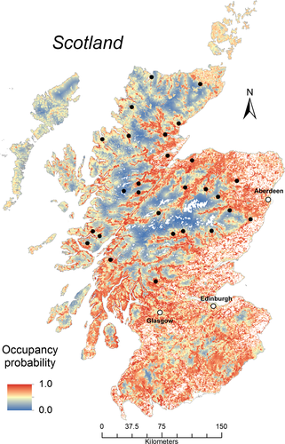

**Figure 1**

Occupancy model predictions for European pine martens *Martes martes* in Scotland, 2010–2013. Black circles are study sites; each site contained an approximate 4 × 5‐km grid of ~20 camera‐trap stations. We sampled sites up to 800 m elevation and comprising up to 86% agricultural land; predictions extrapolated beyond these values were omitted and are represented in white.

Respective inclusion probabilities for proportion coniferous forest and deciduous/mixed woodland in a given 0.25 km<sup>2</sup> cell were 0.98 and 1.0 and both covariates exhibited a strong positive relationship with occupancy (Table 2; Fig. 2a and b).

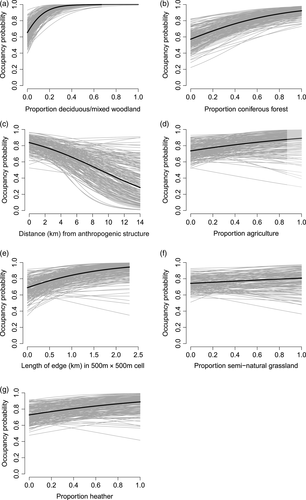

**Figure 2**

Associations between occupancy probability and habitat covariates for European pine martens *Martes martes* in Scotland, 2010–2013. Black lines are model‐averaged mean predictions and gray lines are model‐averaged predictions from a random posterior sample of 150–200 iterations to depict uncertainty. Lightly shaded areas in panels (a) and (d) indicate extrapolative predictions beyond habitat values recorded at study sites (see Supporting Information Table S1).

Inclusion probabilities for all other covariates were low (i.e. ≤0.12; Table 2) and all 95% CIs for these covariates overlapped zero (Table 2). Distance to anthropogenic structure exhibited a weak negative relationship with pine marten occupancy probability (Fig. 2c). Proportion agriculture, proportion semi‐natural grassland, proportion heather and amount of edge in a 0.25 km<sup>2</sup> cell all exhibited weak positive associations with pine marten occupancy probability (Fig. 2d–g).

## Discussion

Here, we used a case study to exhibit how broad‐scale, hierarchical occupancy models can clarify a species’ habitat niche width and position on the generalist–specialist continuum. Specifically, the scale of our assessment captured heterogeneity in a variety of environmental factors, which is crucial for accurately describing niche width (Devictor *et al*., 2010). In addition, the form of our occupancy model accounted for imperfect detection at camera stations and spatial autocorrelation among them, both of which could bias species–habitat associations if unconsidered (Kéry & Schaub, 2012). Given the dual ubiquity of camera‐trapping methods (Burton *et al*., 2015) and occupancy modeling (Royle & Dorazio, 2008), the approach demonstrated here could be broadly applied in a variety of settings to update or refine species’ habitat niche width and position on the generalist–specialist continuum.

To our knowledge, our case study is the first to explicitly quantify high pine marten occurrence in open habitats at broad scales. As such, it corroborates recent evidence from finer scale assessments which illustrated that the habitat niche of pine martens is wider than previously thought (Pereboom *et al*., 2008; Balestrieri *et al*., 2010; Caryl *et al*., 2012a). Others have found a positive relationship between pine martens and ungrazed grasslands (Caryl *et al*., 2012a) and a negative association with agricultural lands (Balharry, 1993; Pereboom *et al*., 2008; Caryl *et al*., 2012a; Manzo *et al*., 2012; Lombardini *et al*., 2015). We found little evidence for such relationships at a broad scale. Given that pine marten home ranges can encompass a variety of habitat types, it is possible that these habitats are preferred or avoided on a finer scale, but do not influence overall pine marten occupancy in Scotland. We conclude that while pine martens are positively associated with woodland/forested habitat, they also occupy a variety of environments, including areas near anthropogenic structure, open habitats such as heather and semi‐natural grasslands and areas containing sizable amounts (i.e. 25–75%) of agricultural land (Figs 1 and 2). In context with other recent studies, our results suggest that at broad scales pine martens are perhaps best classified as moderate habitat generalists that require a relatively modest baseline level of structurally complex, wooded habitat (Balestrieri *et al*., 2010; Mergey, Helder & Roeder, 2011; Caryl *et al*., 2012a; Larroque *et al*., 2016). Other aspects of pine marten ecology, including their behavioral plasticity in relation to mobility, home range size and diet (Bright & Smithson, 1997; Lynch & McCann, 2007; Balestrieri *et al*., 2011; Caryl *et al*., 2012a,b; Virgós *et al*., 2012), support a generalist‐leaning classification, as do studies showing pine martens maintain genetic connectivity in fragmented landscapes (Mergey *et al*., 2011; Larroque *et al*., 2016).

Our case study supports the notion that the degree of habitat specialization observed for a given species can change with scale and context (Devictor *et al*., 2010). For example, Balharry (1993) found pine martens tended to prefer woodland and commercial forest plantations and avoid open areas, but the strength of preference varied by study site and spatial scale (i.e. study site vs. home range). Similarly, Caryl *et al*. (2012a) found pine martens in Scotland selected structurally complex wooded habitats and grasslands while avoiding agriculture and closed‐canopy coniferous stands, but these preferences disappeared within home ranges. In addition, Clevenger (1994) found that pine martens lacked any habitat preference on a Mediterranean island, a result that was attributed to the local absence of predators. More broadly, the majority of studies evaluating habitat preference of pine martens have been conducted in localized, heavily wooded regions of Fennoscandia (e.g. Brainerd, 1990; Storch *et al*., 1990; Brainerd *et al*., 1995; cf. Caryl *et al*., 2012a), have focused on particular seasons (e.g. snow tracking in winter; Storch *et al*., 1990) and/or have relied on modest sample sizes [e.g. Balharry, 1993; Halliwell, 1997; Pereboom *et al*., 2008; and Caryl *et al*., 2012a radiotracked a mean of 8.3 pine martens (sd = 3.4) per study site]. While the conclusions reached by such studies are likely relevant to their particular contexts and scales, our broad‐scale approach contributes to a more generalized classification of pine martens (Devictor *et al*., 2010), with two important caveats. First, our study sites had a moderate mean proportion of woodland (0.43) and the broader area had low densities of humans and anthropogenic structure. Thus, additional work is required to evaluate our results to more populous or heavily deforested regions. Second, our study area lacked one of the pine marten's competitors, the stone marten (*Martes foina*). Due to habitat niche segregation, pine martens inhabiting areas where these species are sympatric might more strongly prefer woodlands than in our study area (Wereszczuk & Zalewski, 2015).

Our approach highlights the importance of accounting for imperfect detection in occupancy models. Ignoring imperfect detection in our study would have resulted in underestimating occupancy by 8.5% (Table 2). Such underestimation could bias generalist–specialist species classifications (Kéry & Schaub, 2012) and might cause conservation concern where it is unwarranted, especially for elusive species (Mackenzie *et al*., 2002). Moreover, our research found an ephemeral trap‐happy response in pine martens, likely due to the use of bait (Kéry & Schaub, 2012). Although recent work on Pacific martens *Martes caurina* suggested their winter habitat associations were biased by baiting (Moriarty *et al*., 2015), we found no evidence of such bias in our study in *post hoc* analysis (i.e. habitat covariates had no relationship with seasonal detection rates, nor with degree of trap happiness). This is likely because we baited less frequently (once every 10–14 days vs. once every 4–5 days) and placed our camera stations much farther apart (~1000 m vs. 50 m) than Moriarty *et al*. (2015).

Agencies interested in conservation actions (e.g. reintroducing pine martens into Wales; MacPherson *et al*., 2014) might use modeling approaches similar to those described here to prioritize efforts for species’ recovery. For instance, our predictions suggest pine martens will occupy habitat near human development or agricultural land, provided the broader area contains a baseline level of wooded habitat (i.e. 0.25 km<sup>2</sup> patches with a minimum of 20–40% wooded cover; cf. Larroque *et al*., 2016; Fig. 2a and b). Our predictive occupancy map comes with the caveat that our survey sites were confined to the Scottish Highlands. However, extrapolated occupancy probabilities for southern Scotland and surrounding islands (Fig. 1), where pine martens are currently scarce, depict areas of habitat that could be targeted for reintroduction or reinforcement efforts, if additional studies validate the suitability of these locations.

## Acknowledgments

R.J.M. is grateful for funding from Michigan State University via a University Distinguished Fellowship, the Ambrose Patullo Fund for Environmental Issues and the Vera. M. Wallach Fellowship and for a Graduate Research Fellowship provided by the National Science Foundation. We are also grateful for the support of the Recanti‐Kaplan Foundation, the European Nature Trust, the People's Trust for Endangered Species, the Aspinall Foundation (K.K. and D.W.M.), Scottish Natural Heritage (K.K.) and the Royal Zoological Society of Scotland (K.K., R.D.C.). M. Bruce, C. McClean, V. Hilton, A. Mitchell, S. Hinshelwood, D. Calder, G. Cumming, B. MacDonald, J. Bain, T. MacDonell, F. Law, Lord Moray, A. W. Featherstone, S. Morris, E. Cameron, G. Vestey, C. Ross, J. Tulloch, G., L. Suggett, P. Crome, A. Henderson, Lord Thurso, P. Sinclair, J., W. Cameron, M. Mitchell, A. Robertson, R. Dennis, A. Davis and R. Scott generously provided access to their land. We thank staff at the Forestry Commission Scotland, Scottish Natural Heritage, National Trust for Scotland, Royal Society for the Protection of Birds, Woodland Trust, Scottish Wildlife Trust and Scottish Wildcat Association. We thank E. Zipkin for modeling guidance and X. Lambin, E. Sheehy and two anonymous reviewers for comments that improved the manuscript.

[figure not shown]

[figure not shown]